# group5_FIHTD_HW1

Caden McQuillen, Yuchen Sun, Xiang (Jennie) Li

2023-02-12

### Load Packages

```r
library(Rcpm) # devtools::install_github("ricoderks/Rcpm")
library(ggplot2)
library(dplyr)
library(tidyverse)
library(ppcor) # install.packages("ppcor")
library(igraph) # install.packages("igraph")
```

## 1. Data Preprocessing

### 1.1 Load data

This is a simulated dataset. Metabolites are in columns and samples are in rows of the `dat` data frame. Annotations of the metabolites can be found in variable `annotations` and information on gender is stored in variable `gender` with 1 = male and 2 = female.

```r
load("Simulated_metabolomics_data.RData")
```

### 1.2 Check data quality

#### Boxplots

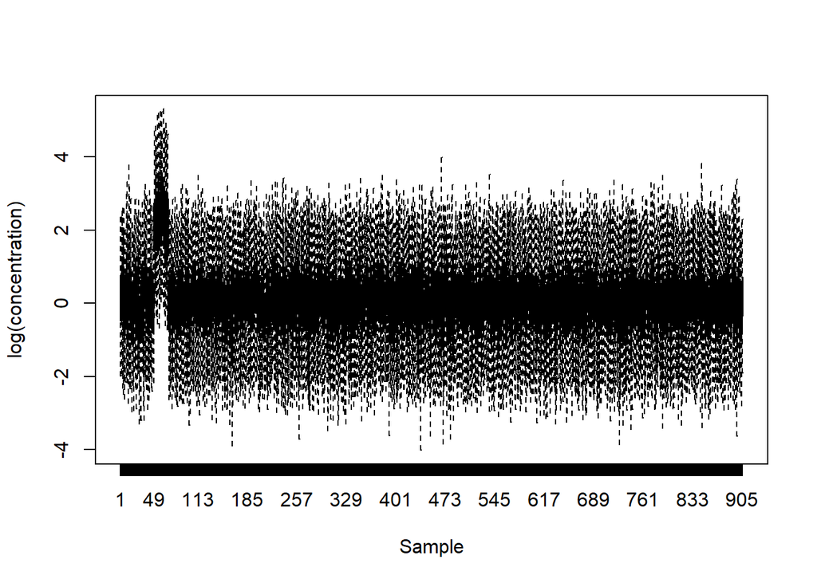

```r
#log data, transpose matrix and covert to dataframe for boxplot function
logged_dat <-data.frame(t(log(dat)))
#rename colnames as 1-906
colnames(logged_dat)<-seq(1:906)
#create boxplot, dont plot outliers
samples_boxplot <-boxplot(logged_dat, xlab = "Sample", ylab = "log(concentration)" , outline = FALSE)
```

Observation: Sample 50 - 80 have higher concentrations compared to other samples. These samples may happened to contain more cells so the total concentration of metabolites are higher than normal.

### 1.3 Quotient normalization

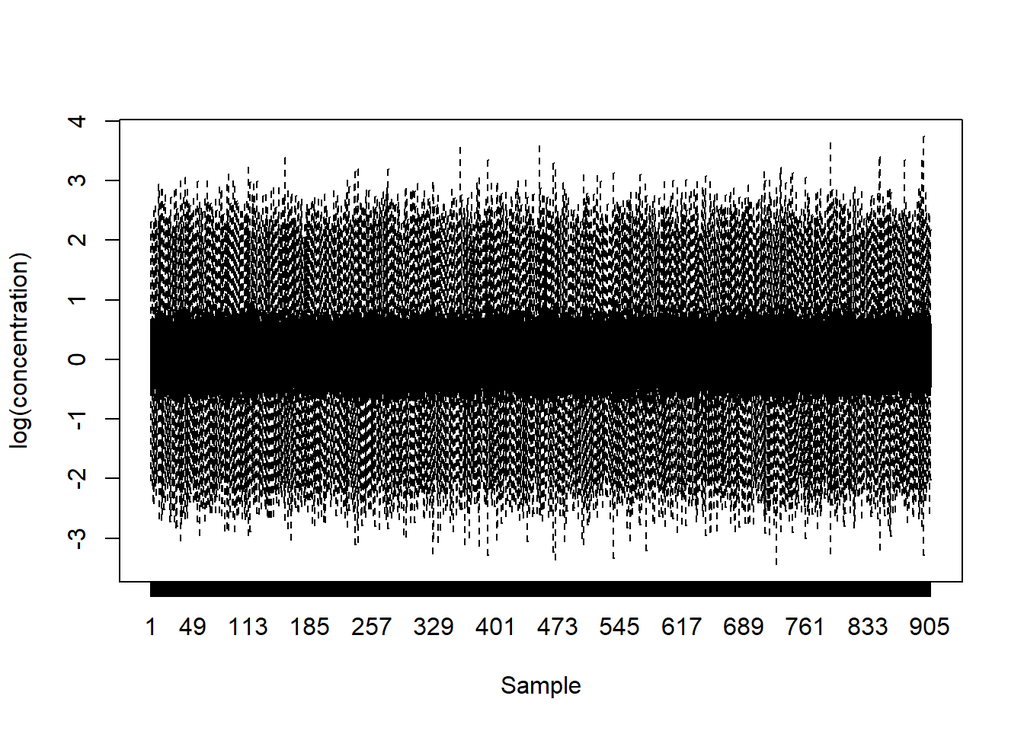

```r
#quotient normalization using Dieterle, F., Ross, A., Schlotterbeck, G. & Senn, H. Probabilistic Quotient Normalization as Robust Method to Account for Dilution of Complex Biological Mixtures. Application in H1 NMR Metabonomics. Anal. Chem. 78, 4281-4290 (2006).
normalized_dat <-pqn(dat,QC=NULL)

#log data, transpose matrix and covert to dataframe for boxplot function
norm_logged_dat <-data.frame(t(log(normalized_dat)))
#rename colnames as 1-906
colnames(norm_logged_dat)<-seq(1:906)
#create boxplot, dont plot outliers
norm_samples_boxplot <-boxplot(norm_logged_dat, xlab = "Sample", ylab = "log(concentration)" , outline = FALSE)
```

## 2. Phenotype Association

### 2.1 Metabolite differences between males and females (t-test)

```r
#get indices of males and females
males <- which(gender == 1)
females <-which(gender ==2)
#subset normalized matrix by male and female
male_metabolites_norm_dat <- normalized_dat[males,]
female_metabolites_norm_dat <-normalized_dat[females,]
#vector to hold p values for each metabolite
pvals <- c()
log2fold <- c()
#for each metabolite, do t-test comparing concentration between males and females
for (i in 1:length(colnames(normalized_dat))){
  male_sample <- male_metabolites_norm_dat[,i]
  female_sample <- female_metabolites_norm_dat[,i]
  temp <- t.test(male_sample,female_sample)
  pvals[i] <- temp$p.value
  log2fold[i] <- log2(mean(male_sample))-log2(mean(female_sample))
}
```

### 2.2 Plot p-values

```r
# create dataframe for volcano plot, contains log2fold change, p-value, metabolites name, and labels for differentially expressed metabolites
de <- data.frame(log2fold,pvals,annotations$name)
names(de) <- c('log2FoldChange','pvalue','name')
# categorize whether metabolites are expressed differently in M or F
de$diffexp <- 'No Diff'
de$diffexp[de$pvalue<0.05 & de$log2FoldChange>0] <- 'High in Male'
de$diffexp[de$pvalue<0.05 & de$log2FoldChange<0] <- 'High in Female'
# create labels for highly differentially expressed metabolites
de$delabel <- NA
de$delabel[de$diffexp!='No Diff' & abs(de$log2FoldChange)>1] <- de$name[de$diffexp!='No Diff' & abs(de$log2FoldChange)>1]
```

#### Histogram

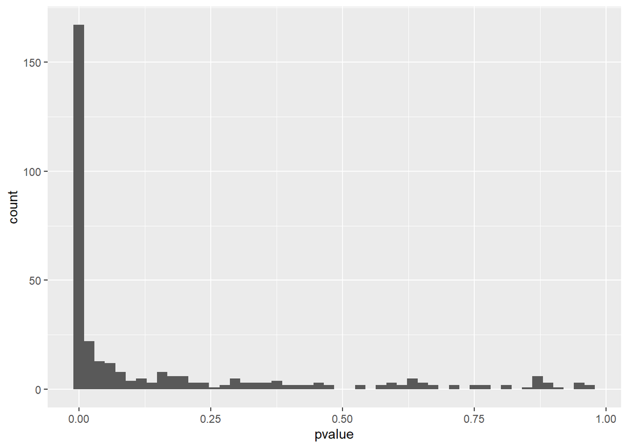

```r
# create histogram
ggplot(de, aes(x=pvalue)) + geom_histogram(bins=50)
```

#### Volcano Plots

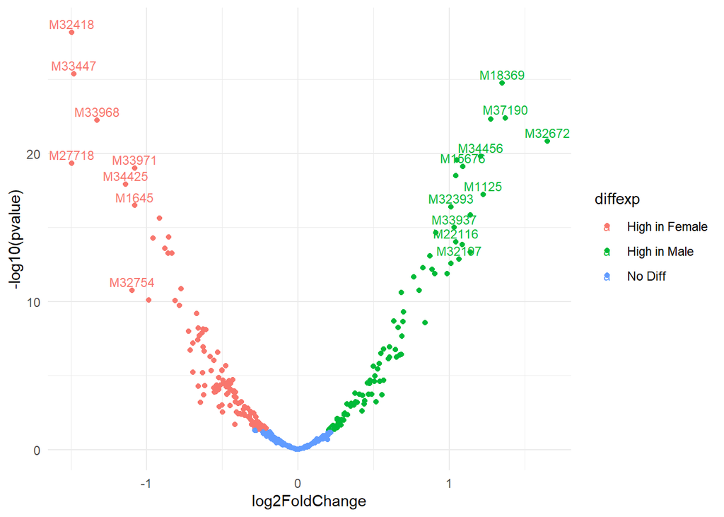

```r
# create volcano plot
ggplot(data=de, aes(x=log2FoldChange,y=-log10(pvalue),col=diffexp,label=delabel)) + geom_point() + theme_minimal() + geom_text(check_overlap=T,size=3,vjust=0,nudge_y=0.25)
```

#### Multiple testing correction

Method: FDR $\alpha$: 0.05

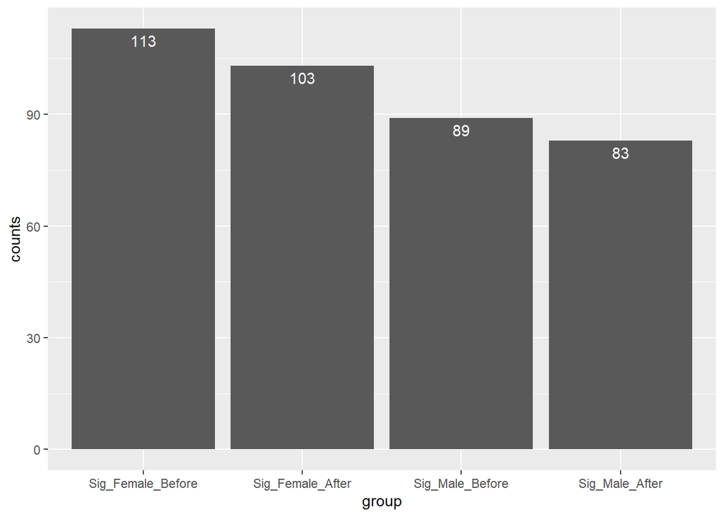

```r
#copy DE dataframe and keep only metabolite name, logFC, p value
de_adj <-de
de_adj <- de_adj[,c(1,2,3)]
#add adjusted p value using FDR
de_adj$p.adj <-p.adjust(de_adj$pvalue, method = "fdr")

#Relabel metabolites after correction
de_adj$diffexp <- 'No Diff'
de_adj$diffexp[de_adj$p.adj<0.05 & de_adj$log2FoldChange>0] <- 'High in Male'
de_adj$diffexp[de_adj$p.adj<0.05 & de_adj$log2FoldChange<0] <- 'High in Female'
# create labels for highly differentially expressed metabolites
de_adj$delabel <- NA
de_adj$delabel[de_adj$diffexp!='No Diff' & abs(de_adj$log2FoldChange)>1] <- de_adj$name[de_adj$diffexp!='No Diff' & abs(de_adj$log2FoldChange)>1]

#count significant metabolites for each group
sig_female_before = length(which(de$diffexp == "High in Female"))
sig_male_before = length(which(de$diffexp == "High in Male"))

sig_female_after = length(which(de_adj$diffexp == "High in Female"))
sig_male_after = length(which(de_adj$diffexp == "High in Male"))

#create dataframe for barplot
counts <- c(sig_female_before,sig_male_before, sig_female_after, sig_male_after)
group <- c("Sig_Female_Before", "Sig_Male_Before", "Sig_Female_After", "Sig_Male_After")
barplot_df <- data.frame(group,counts )

#barplot
ggplot(data=barplot_df, aes(x=group, y=counts)) +
  geom_bar(stat="identity") +
    geom_text(aes(label = counts), vjust = 1.5, colour = "white") +
  scale_x_discrete(limits=c("Sig_Female_Before","Sig_Female_After","Sig_Male_Before", "Sig_Male_After"))
```

113 metabolites are significantly associated with female before multiple testing correction and 103 after. 89 metabolites are significantly associated with male before multiple testing correction and 83 after.

### 2.3 Gender association & pathways

#### Order by p.adj

```r
# order metabolites by adjusted p-values
de_ordered <- de_adj[order(de_adj$p.adj),]
head(de_ordered)
```

```
##     log2FoldChange       pvalue   name        p.adj        diffexp delabel
## 186      -1.495694 6.698564e-29 M32418 2.244019e-26 High in Female  M32418
## 208      -1.479115 4.086259e-26 M33447 6.844484e-24 High in Female  M33447
## 143       1.348383 1.732119e-25 M18369 1.934199e-23   High in Male  M18369
## 87        1.369210 4.099943e-23 M37190 3.135931e-21   High in Male  M37190
## 189       1.273924 4.680495e-23 M43488 3.135931e-21   High in Male  M43488
## 84       -1.328953 5.744931e-23 M33968 3.207587e-21 High in Female  M33968
```

#### Metabolites associated with gender

```r
# get top DE metab
top.male.met <- as.data.frame(de_ordered) %>% dplyr::filter(log2FoldChange > 0) %>%
    pull('name') %>% head(5)
top.female.met <- as.data.frame(de_ordered) %>% dplyr::filter(log2FoldChange < 0) %>%
    pull('name') %>% head(5)

top.male.met
```

```
## [1] "M18369" "M37190" "M43488" "M32672" "M34456"
```

```r
top.female.met
```

```
## [1] "M32418" "M33447" "M33968" "M27718" "M33971"
```

#### Visualization

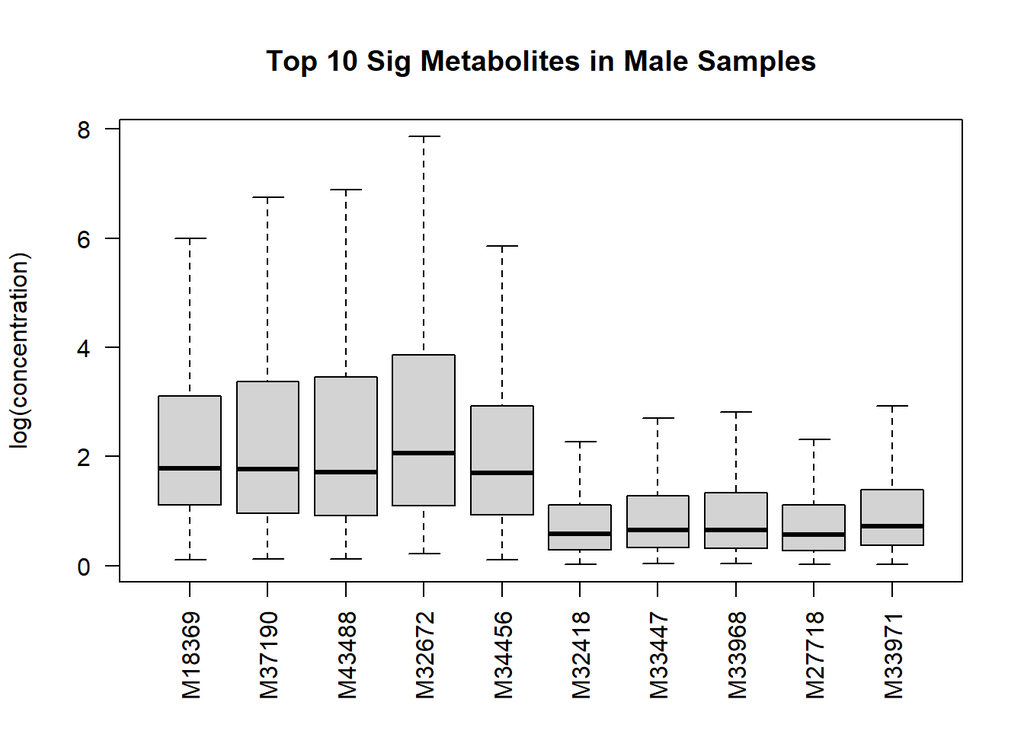

```r
top.metabs <- c(top.male.met, top.female.met)
sig_metabs_male <- male_metabolites_norm_dat[, top.metabs ]
sig_metabs_female <- female_metabolites_norm_dat[, top.metabs ]
#create boxplot, dont plot outliers
colors = c(rep("red",5),rep("blue",5))
norm_samples_boxplot <-boxplot(sig_metabs_male, main = "Top 10 Sig Metabolites in Male Samples", ylab = "log(concentration)" , outline = FALSE, show.names=TRUE, las=2)
```

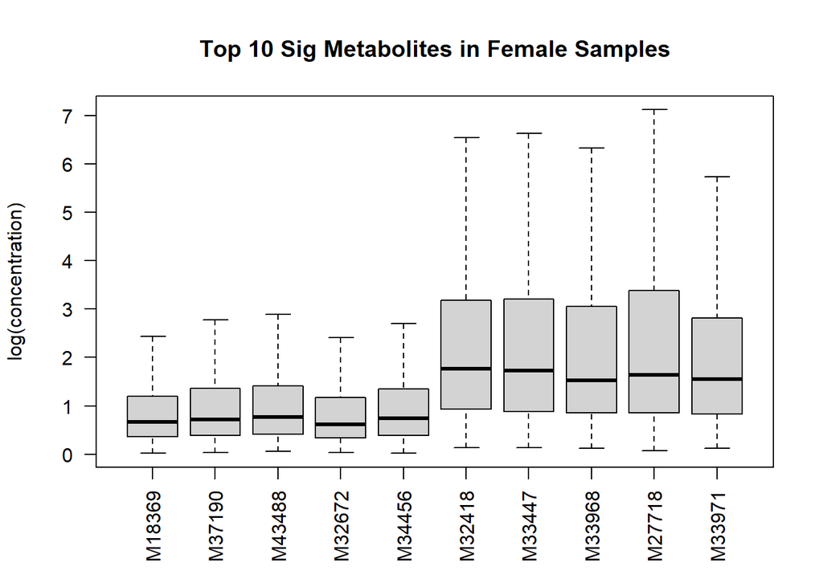

```r
norm_samples_boxplot <-boxplot(sig_metabs_female, main = "Top 10 Sig Metabolites in Female Samples", ylab = "log(concentration)" , outline = FALSE, show.names=TRUE, las=2)
```

## 3. Gaussian graphical model (GGM)

### 3.1 Calculate partial correlations

```r
#use the ppcor package on normalized matrix
dat_pcor <- pcor(normalized_dat)
```

### 3.2 Multiple testing correction

When calculating the number of tests, remember that a correlation matrix is symmetric and the diagonal does not count (calculate how many values there are in a correlation matrix). Set all insignificant values and the in the partial correlation matrix to zero.

Method: Bonferroni $\alpha$: 0.05

```r
alpha = 0.05

#copy DE dataframe
dat_pcor_adj <- dat_pcor


#add adjusted p value using bonferroni

#get upper triangular matrix of correlation matrix p values
indices_to_keep <- upper.tri(dat_pcor_adj$p.value)
#subset matrix to only upper triangular matrix
dat_pcor_adj$p.value <- dat_pcor_adj$p.value[indices_to_keep]
#adjust p values using bonferroni, n = length(dat_pcor_adj$p.value) = ((335*335)-335)/2 aka upper triangular matrix of 335x335
dat_pcor_adj$p.adj <- p.adjust(dat_pcor_adj$p.value, method = "bonferroni")


#label significant and insignificant values
dat_pcor_adj$sig <- c(dat_pcor_adj$p.adj)
dat_pcor_adj$sig[de_adj$p.adj > alpha] <- "Not Significant"
dat_pcor_adj$sig[de_adj$p.adj < alpha] <- 'Significant'

#count significant metabolites
sig_metab = length(which(dat_pcor_adj$sig == "Significant"))
insig_metab = length(which(dat_pcor_adj$sig == "Not Significant"))



#convert entries in correlation matrix that are insignificant to 0
for(i in 1:335){
  for(j in 1:335){
    if(i*j > length(dat_pcor_adj$sig)){
      break
    }
    if(i == j ){
      dat_pcor_adj$estimate[i,j] <-0
    }
    else{
      if(dat_pcor_adj$sig[i*j] == "Not Significant"){
         dat_pcor_adj$estimate[i,j] <-0
          dat_pcor_adj$estimate[j,i] <-0
      }
    }
  }
}
```

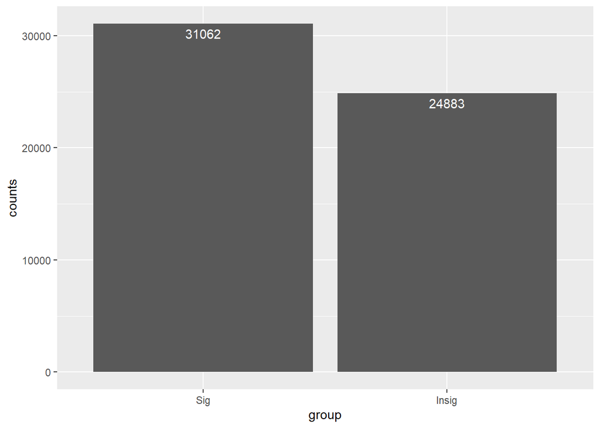

```r
#create dataframe for barplot
counts <- c(sig_metab, insig_metab)
group <- c("Sig", "Insig")
barplot_df <- data.frame(group,counts)

#barplot
ggplot(data=barplot_df, aes(x=group, y=counts)) +
  geom_bar(stat="identity") +
    geom_text(aes(label = counts), vjust = 1.5, colour = "white") +
  scale_x_discrete(limits=c("Sig", "Insig"))
```

### 3.3 Visualize the network

This matrix is the adjacency matrix of the underlying Gaussian graphical model. Visualize the network using the igraph package (tip: graph.adjacency function).

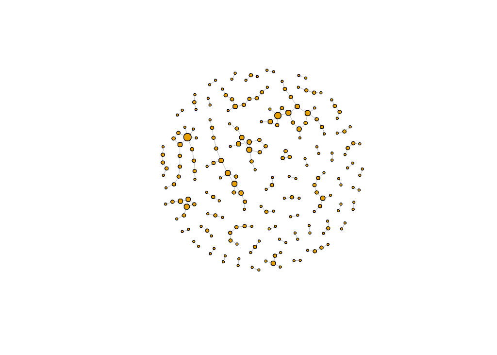

```r
g <- simplify(graph.adjacency(dat_pcor_adj$estimate,mode="undirected",weighted=T,diag=F))
g <- delete.edges(g,E(g)[abs(weight)<0.2])
g <- delete.vertices(g,degree(g)==0)
plot.igraph(g,vertex.size=degree(g)+2,vertex.label=NA,edge.width=abs(E(g)$weight),layout=layout.auto(g))
```